# Week 1 exercises

Dmitry Kondrashov and Stefano Allesina

Selected exercises taken from Grolemund & Wickham, Chapter 3.

In this assignment you will learn the following:

- Use ggplot to plot several geom(etries)
- Map variables to aes(thetics)
- Plot trend curves
- Make multiple plots using facet
- Make barplots and histograms
- Summarize distributions of variables

## Section 3.2.4

4. Make a scatterplot of hwy vs cyl.

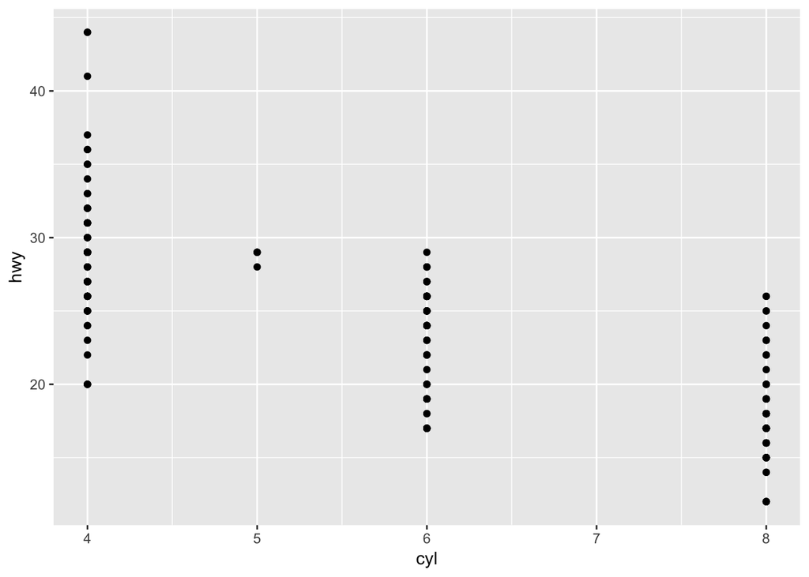

```r
ggplot(data = mpg) +
  geom_point(mapping = aes(x = cyl, y = hwy))
```

5. What happens if you make a scatterplot of class vs drv? Why is the plot not useful?

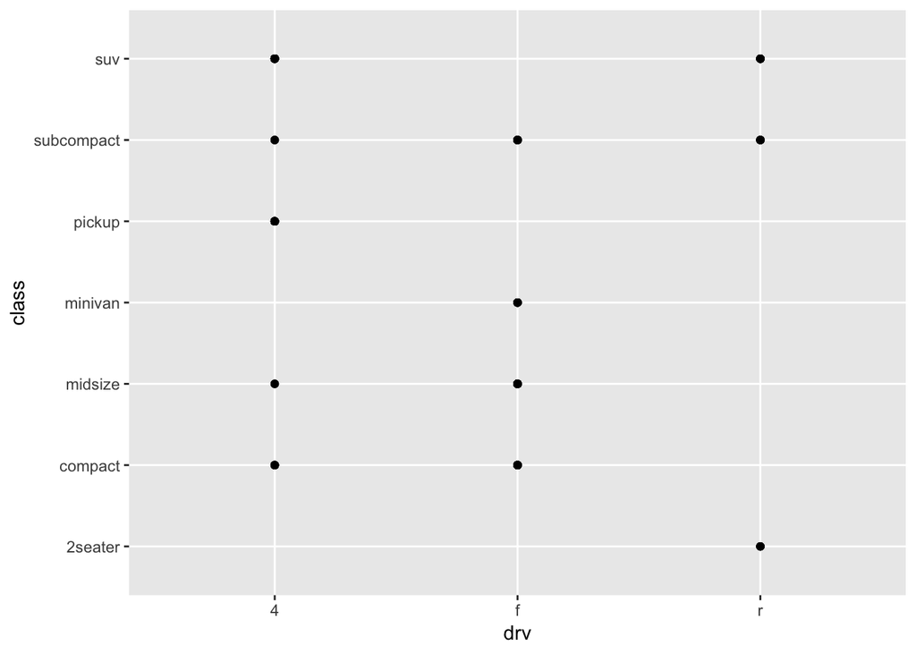

```r
ggplot(data = mpg) +
  geom_point(mapping = aes(x = drv, y = class))
```

The variables are categorical, so a scatterplot doesn’t show a relationship or trend.